# Homework2

```python
# Import modules
import numpy as np
import pandas as pd
import seaborn as sns
import bokeh as bk
import re
import random
from bokeh.io import output_notebook, show
output_notebook()
%matplotlib inline
import matplotlib.pyplot as plt
```

```python
# Ignore irrelevant warnings
import warnings
warnings.filterwarnings('ignore')
```

```python
# 设置整体绘图打印样式
%config InlineBackend.figure_format='retina'
sns.set()
plt.rcParams['figure.figsize'] = (11, 6)
plt.rcParams['axes.labelpad'] = 10
sns.set_style("darkgrid")
# sns.set_palette("Reds")
# sns.set_context("poster", font_scale=1.0)

pd.set_option('max_colwidth',80)
```

## 加载csv文件，并将数据整合到一个DataFrame

### 加载文件，并调整属性位置，统一所有的列

```python
# 属性列表
column_names = ['agency', 'createTime', 'location', 'areaId', 'beat', 'priority',
       'incidentTypeId', 'incidentTypeDescription', 'eventNumber','closedTime']
# 从CSV文件中读取数据, 并将时间属性值格式化
Crime11DF = pd.read_csv("F:/Data Mining/Oakland crime/oakland-crime-statistics-2011-to-2016/records-for-2011.csv", sep=",", header=0,
                        skip_blank_lines=True, parse_dates=['Create Time','Closed Time'])
Crime12DF = pd.read_csv("F:/Data Mining/Oakland crime/oakland-crime-statistics-2011-to-2016/records-for-2012.csv", sep=",", header=0,
                        skip_blank_lines=True, parse_dates=['Create Time','Closed Time'])
Crime13DF = pd.read_csv("F:/Data Mining/Oakland crime/oakland-crime-statistics-2011-to-2016/records-for-2013.csv", sep=",", header=0,
                        skip_blank_lines=True, parse_dates=['Create Time','Closed Time'])
Crime14DF = pd.read_csv("F:/Data Mining/Oakland crime/oakland-crime-statistics-2011-to-2016/records-for-2014.csv", sep=",", header=0,
                        skip_blank_lines=True, parse_dates=['Create Time','Closed Time'])
Crime15DF = pd.read_csv("F:/Data Mining/Oakland crime/oakland-crime-statistics-2011-to-2016/records-for-2015.csv", sep=",", header=0,
                        skip_blank_lines=True, parse_dates=['Create Time','Closed Time'])
Crime16DF = pd.read_csv("F:/Data Mining/Oakland crime/oakland-crime-statistics-2011-to-2016/records-for-2016.csv", sep=",", header=0,
                        skip_blank_lines=True, parse_dates=['Create Time','Closed Time'])
```

```python
# 调整列位置，并删除zipCode列
Crime12DF = Crime12DF[['Agency', 'Create Time', 'Location 1', 'Area Id', 'Beat', 'Priority',
       'Incident Type Id', 'Incident Type Description', 'Event Number','Closed Time']]
Crime14DF = Crime12DF[['Agency', 'Create Time', 'Location 1', 'Area Id', 'Beat', 'Priority',
       'Incident Type Id', 'Incident Type Description', 'Event Number','Closed Time']]
```

### 数据处理，从Location 1属性中提取能用的Location属性值

```python
def extractAddress (x) :
    x = str(x)
    resGroup = re.search(r'address": "(.*?)"',x)
    if resGroup !=None:
        x = resGroup.group().replace('"',"").replace("address: ","")
    else:
        x = None
    return(x)
# 提取address信息并替换 Location 1 属性的值
Crime12DF['Location 1'] = Crime12DF['Location 1'].apply(extractAddress)
Crime14DF['Location 1'] = Crime14DF['Location 1'].apply(extractAddress)
```

### 合并数据集，并重建索引

```python
Crime11DF.columns = column_names
Crime12DF.columns = column_names
Crime13DF.columns = column_names
Crime14DF.columns = column_names
Crime15DF.columns = column_names
Crime16DF.columns = column_names
# 按行将数据集合并成新Dataframe
CrimeDF = pd.concat([Crime11DF,Crime12DF,Crime13DF,Crime14DF,Crime15DF,Crime16DF])
# 重新建立索引
CrimeDF.reset_index(inplace=True,drop=True)
```

```python
CrimeDF.info()
```

```
<class 'pandas.core.frame.DataFrame'>
RangeIndex: 1046339 entries, 0 to 1046338
Data columns (total 10 columns):
 #   Column                   Non-Null Count    Dtype
---  ------                   --------------    -----
 0   agency                   1046334 non-null  object
 1   createTime               1046334 non-null  datetime64[ns]
 2   location                 1046199 non-null  object
 3   areaId                   1040346 non-null  object
 4   beat                     1040767 non-null  object
 5   priority                 1046334 non-null  float64
 6   incidentTypeId           1046334 non-null  object
 7   incidentTypeDescription  1046087 non-null  object
 8   eventNumber              1046334 non-null  object
 9   closedTime               1046291 non-null  datetime64[ns]
dtypes: datetime64[ns](2), float64(1), object(7)
memory usage: 79.8+ MB
```

### 因为要分析的是时间差和其他属性之间的关联关系，而不是“创建时间”与“结束时间”与其他属性之间的关联关系。所 以生成`handingTime`列，单位是分钟

```python
CrimeDF['handingTime'] = (CrimeDF['closedTime']-CrimeDF['createTime']).dt.seconds/60
CrimeDF
```

|  | agency | createTime | location | areaId | beat | priority | incidentTypeId | incidentTypeDescription | eventNumber | closedTime | handingTime |
| --- | --- | --- | --- | --- | --- | --- | --- | --- | --- | --- | --- |
| 0 | OP | 2011-01-01 00:00:00 | ST&SAN PABLO AV | 1 | 06X | 1.0 | PDOA | POSSIBLE DEAD PERSON | LOP110101000001 | 2011-01-01 00:28:17 | 28.283333 |
| 1 | OP | 2011-01-01 00:01:11 | ST&HANNAH ST | 1 | 07X | 1.0 | 415GS | 415 GUNSHOTS | LOP110101000002 | 2011-01-01 01:12:56 | 71.750000 |
| 2 | OP | 2011-01-01 00:01:25 | ST&MARKET ST | 1 | 10Y | 2.0 | 415GS | 415 GUNSHOTS | LOP110101000003 | 2011-01-01 00:07:20 | 5.916667 |
| 3 | OP | 2011-01-01 00:01:35 | PRENTISS ST | 2 | 21Y | 2.0 | 415GS | 415 GUNSHOTS | LOP110101000005 | 2011-01-01 00:02:28 | 0.883333 |
| 4 | OP | 2011-01-01 00:02:10 | AV&FOOTHILL BLVD | 2 | 20X | 1.0 | 415GS | 415 GUNSHOTS | LOP110101000004 | 2011-01-01 00:50:04 | 47.900000 |
| ... | ... | ... | ... | ... | ... | ... | ... | ... | ... | ... | ... |
| 1046334 | OP | 2016-07-31 23:45:50 | WHITMORE ST&WOOD ST | P1 | 02Y | 2.0 | 415GS | 415 GUNSHOTS | LOP160731000892 | 2016-07-31 23:58:03 | 12.216667 |
| 1046335 | OP | 2016-07-31 23:50:54 | WHITTLE 69TH AV | P3 | 26Y | 2.0 | 415N | DISTURBANCE-NEIGHBOR | LOP160731000893 | 2016-08-01 00:08:00 | 17.100000 |
| 1046336 | OP | 2016-07-31 23:56:29 | WHITTLE LOOMIS CT | P2 | 19X | 2.0 | 912 | SUSPICIOUS PERSON | LOP160731000895 | 2016-08-01 01:33:31 | 97.033333 |
| 1046337 | OP | 2016-07-31 23:57:31 | WYMAN LACEY AV | P3 | 29X | 2.0 | 415 | 415 FAMILY | LOP160731000897 | 2016-08-01 00:16:16 | 18.750000 |
| 1046338 | NaN | NaT |  | NaN | NaN | NaN | NaN | NaN | NaN | NaT | NaN |

1046339 rows × 11 columns

```python
CrimeDF[CrimeDF['handingTime']>1000]
```

|  | agency | createTime | location | areaId | beat | priority | incidentTypeId | incidentTypeDescription | eventNumber | closedTime | handingTime |
| --- | --- | --- | --- | --- | --- | --- | --- | --- | --- | --- | --- |
| 131 | OP | 2011-01-01 03:20:26 | 78TH AV | 3 | 30X | 1.0 | 901 | VEHICLE COLLISION-DR | LOP110101000226 | 2011-01-02 00:06:06 | 1245.666667 |
| 536 | OP | 2011-01-02 02:30:19 | 35TH AV | 2 | 24Y | 1.0 | 941 | PERSON DETAINED-IN C | LOP110102000101 | 2011-01-03 00:36:49 | 1326.500000 |
| 551 | OP | 2011-01-02 04:07:09 | MIDVALE AV | 2 | 22Y | 1.0 | 242 | BATTERY | LOP110102000130 | 2011-01-02 22:59:44 | 1132.583333 |
| 665 | OP | 2011-01-02 13:50:53 | MAKIN RD | 3 | 31Y | 1.0 | CODE7 | SUBJECT ARMED WITH W | LOP110102000385 | 2011-01-03 08:20:28 | 1109.583333 |
| 929 | OP | 2011-01-03 04:55:27 | AV&WALKER AV | 2 | 14Y | 1.0 | 940A | COVER THE OFFICER | LOP110103000140 | 2011-01-03 22:18:22 | 1042.916667 |
| ... | ... | ... | ... | ... | ... | ... | ... | ... | ... | ... | ... |
| 1046103 | OP | 2016-07-31 14:04:18 | W ST&FRANKLIN ST | POU | 03X | 2.0 | 597 | CRUELTY TO ANIMAL | LOP160731000452 | 2016-08-01 11:37:28 | 1293.166667 |
| 1046130 | OP | 2016-07-31 15:22:33 | W ST&FRANKLIN ST | POU | 03X | 2.0 | 597 | CRUELTY TO ANIMAL | LOP160731000514 | 2016-08-01 11:38:08 | 1215.583333 |
| 1046155 | OP | 2016-07-31 16:03:21 | W BROADWAY | P1 | 08X | 2.0 | 953 | INVESTIGATE REPORT O | LOP160731000556 | 2016-07-31 16:03:20 | 1439.983333 |
| 1046178 | OP | 2016-07-31 17:05:06 | W OLIVE ST | P3 | 34X | 2.0 | 415GF | GIRLFRIEND CREATING | LOP160731000597 | 2016-08-03 12:06:50 | 1141.733333 |
| 1046204 | OP | 2016-07-31 18:13:39 | W E 30TH ST | P2 | 18Y | 2.0 | 10851 | STOLEN VEHICLE | LOP160731000645 | 2016-08-01 11:12:07 | 1018.466667 |

12214 rows × 11 columns

## 数据清洗

### 由于空元组数目相对于全部100w条数据较少，因此删除空属性元组不影响对数据集的分析

```python
# 删除空元组
CrimeDF.dropna(how="any",inplace=True)
CrimeDF.isnull().sum()
```

```
agency                     0
createTime                 0
location                   0
areaId                     0
beat                       0
priority                   0
incidentTypeId             0
incidentTypeDescription    0
eventNumber                0
closedTime                 0
handingTime                0
dtype: int64
```

```python
len(CrimeDF)
```

```
1035436
```

### 提取数据集中可分析属性

```python
## 创建需要分析的数据列表
SubDF = CrimeDF[['location', 'areaId', 'beat', 'incidentTypeId', 'handingTime']]
#SubDF = SubDF.sample(n=200000,random_state=12315,axis=0)
```

### 对数据进行处理转换成可以进行关联规则挖掘的形式，对于数值型数据进行分层

```python
def normalizef(x):
    x['location'] = "Location_"+x['location'].strip()
    x['beat'] = 'Beat_'+x['beat'].strip()
    x['incidentTypeId'] = 'IncTypeId_'+x['incidentTypeId'].strip()
    x['areaId'] = 'AreaId_'+str(x['areaId'])
#     x['priority'] = 'Priority' + str(x['priority'])
    s = x['handingTime']
    if s > 60*24*3:
        s = 'HandingTime'+'3d'
    elif (s > 60*24*2) and (s <= 60*24*3):
        s = 'HandingTime_'+'2d_3d'
    elif s > 60*24 and s <= 60*24*2:
        s = 'HandingTime_'+'1d_2d'
    elif s >60*20 and s<=60*24:
        s = 'HandingTime_'+'20h_24h'
    elif s >60*16 and s<=60*20:
        s = 'HandingTime_'+'16h_20h'
    elif s >60*12 and s<=60*16:
        s = 'HandingTime_'+'12h_16h'
    elif s >60*8 and s<=60*12:
        s = 'HandingTime_'+'8h_12h'
    elif s >60*4 and s<=60*8:
        s = 'HandingTime_'+'4h_8h'
    elif s >60*1 and s<=60*4:
        s = 'HandingTime_'+'1h_4h'
    elif s<=60:
        s = 'HandingTime_'+'1h'
    x['handingTime'] = s
    return x
SubDF = SubDF.apply(normalizef, axis=1)
```

```python
SubDF
```

|  | location | areaId | beat | incidentTypeId | handingTime |
| --- | --- | --- | --- | --- | --- |
| 0 | Location_ST&SAN PABLO AV | AreaId_1.0 | Beat_06X | IncTypeId_PDOA | HandingTime_1h |
| 1 | Location_ST&HANNAH ST | AreaId_1.0 | Beat_07X | IncTypeId_415GS | HandingTime_1h_4h |
| 2 | Location_ST&MARKET ST | AreaId_1.0 | Beat_10Y | IncTypeId_415GS | HandingTime_1h |
| 3 | Location_PRENTISS ST | AreaId_2.0 | Beat_21Y | IncTypeId_415GS | HandingTime_1h |
| 4 | Location_AV&FOOTHILL BLVD | AreaId_2.0 | Beat_20X | IncTypeId_415GS | HandingTime_1h |
| ... | ... | ... | ... | ... | ... |
| 1046333 | Location_WENDY'S ST&PINE ST | AreaId_P1 | Beat_02Y | IncTypeId_922 | HandingTime_1h |
| 1046334 | Location_WHITMORE ST&WOOD ST | AreaId_P1 | Beat_02Y | IncTypeId_415GS | HandingTime_1h |
| 1046335 | Location_WHITTLE 69TH AV | AreaId_P3 | Beat_26Y | IncTypeId_415N | HandingTime_1h |
| 1046336 | Location_WHITTLE LOOMIS CT | AreaId_P2 | Beat_19X | IncTypeId_912 | HandingTime_1h_4h |
| 1046337 | Location_WYMAN LACEY AV | AreaId_P3 | Beat_29X | IncTypeId_415 | HandingTime_1h |

1035436 rows × 5 columns

### 对全部不重复属性值进行One-hot编码，并生成编码和解码字典，方便规则的转换。然后将所有元组转换成向量表示

```python
strSet = SubDF['location'].unique().tolist()+SubDF['areaId'].unique().tolist()+SubDF['beat'].unique().tolist()+SubDF['incidentTypeId'].unique().tolist()+SubDF['handingTime'].unique().tolist()
#+SubDF['priority'].unique().tolist()
```

```python
import orangecontrib.associate.fpgrowth as oaf  #进行关联规则分析的包

strEncode = dict(zip(strSet,range(len(strSet)))) #编码字典
strDecode = dict(zip(strEncode.values(), strEncode.keys()))  #解码字典

def toNum(x):
    x['location'] = strEncode[x['location']]
    x['beat'] = strEncode[x['beat']]
    x['incidentTypeId'] = strEncode[x['incidentTypeId']]
    x['areaId'] = strEncode[x['areaId']]
#     x['priority'] =strEncode[x['priority']]
    x['handingTime'] = strEncode[x['handingTime']]
    return x

# 将全部元组转化成向量表示
AnalysisDF = SubDF.apply(toNum, axis=1)
```

```python
itemsets = dict(oaf.frequent_itemsets(AnalysisDF.values.tolist(),  .0025))
rules = oaf.association_rules(itemsets, .65)   #设置置信度
rules = list(rules)
```

```python
print(len(rules))
```

```
118
```

```python
# 查看频繁项集
itemsets
```

```
{frozenset({106088}): 491824,
 frozenset({106089}): 389351,
 frozenset({105737}): 385035,
 frozenset({105737, 106088}): 193411,
 frozenset({105737, 106089}): 147407,
 frozenset({105738}): 316491,
 frozenset({105738, 106088}): 141262,
 frozenset({105738, 106089}): 120532,
 frozenset({105740}): 128448,
 frozenset({105740, 106088}): 54981,
 frozenset({105740, 106089}): 44830,
 frozenset({105741}): 113709,
 frozenset({105741, 106088}): 58591,
 frozenset({105741, 106089}): 42222,
 frozenset({106091}): 100393,
 frozenset({105737, 106091}): 31899,
 frozenset({105738, 106091}): 35033,
 frozenset({105740, 106091}): 15846,
 frozenset({105741, 106091}): 9222,
 frozenset({105811}): 97887,
 frozenset({105811, 106088}): 60456,
 frozenset({105737, 105811}): 41028,
 frozenset({105737, 105811, 106088}): 26813,
 frozenset({105738, 105811}): 25947,
 frozenset({105738, 105811, 106088}): 15014,
 frozenset({105811, 106091}): 6989,
 frozenset({105811, 106089}): 27125,
 frozenset({105737, 105811, 106089}): 11145,
 frozenset({105738, 105811, 106089}): 7387,
 frozenset({105740, 105811}): 11436,
 frozenset({105740, 105811, 106088}): 6164,
 frozenset({105740, 105811, 106089}): 2993,
 frozenset({105741, 105811}): 11717,
 frozenset({105741, 105811, 106088}): 7415,
 frozenset({105741, 105811, 106089}): 3415,
 frozenset({105813}): 67255,
 frozenset({105813, 106088}): 48578,
 frozenset({105737, 105813}): 24383,
 frozenset({105737, 105813, 106088}): 17688,
 frozenset({105738, 105813}): 19211,
```

[output cut: 862 more lines]

```
 frozenset({337}): 3004,
 frozenset({105854}): 2911,
 frozenset({105806}): 2887,
 frozenset({250}): 2885,
 frozenset({158}): 2884,
 frozenset({105832}): 2851,
 frozenset({105847}): 2831,
 frozenset({105873}): 2774,
 frozenset({32005}): 2767,
 frozenset({105872}): 2721,
 frozenset({161}): 2719,
 frozenset({74}): 2649,
 frozenset({105843}): 2627,
 frozenset({586}): 2612,
 frozenset({433}): 2607}
```

### 打印挖掘出的规则, 并使用Lift、Kulc和IR指标，评价关联规则

```python
 def dealRules(rules,strDecode):
    returnRules = []
    for i in rules:
        temList = []
        pb = i[3]/i[6]
        pa = i[4]
        pab = i[3]*pa
        temStr = '( ';
        for j in i[0]:   #处理第一个frozenset
            temStr = temStr+strDecode[j]+', '
        temStr = temStr[:-2]+' )'
        temStr = temStr + ' ==> ('
        for j in i[1]:
            temStr = temStr+strDecode[j] + ', '
        temStr = temStr[:-2]+' )'
        temList.append(temStr); temList.append(i[2]); temList.append(i[3]); temList.append(i[6]);
#         temList.append(0.5*(i[3]+i[3]/i[5]))
        temList.append(0.5*(pab/pa+pab/pb))
        temList.append(abs(pa-pb)/(pa+pb-pab))
        temList.append(pa)
        temList.append(pb)
        temList.append(pab)
        returnRules.append(temList)
    return pd.DataFrame(returnRules,columns=('规则','支持度','置信度','Lift','Kulc','IR','SupA','SupB','SupAB'))

#printRules = dealRules(rules,strDecode)
```

```python
result = list(oaf.rules_stats(rules, itemsets, len(AnalysisDF)))
```

```python
StateDF = dealRules(result,strDecode)
StateDF
```

|  | 规则 | 支持度 | 置信度 | Lift | Kulc | IR | SupA | SupB | SupAB |
| --- | --- | --- | --- | --- | --- | --- | --- | --- | --- |
| 0 | ( IncTypeId_911H, AreaId_1.0, Beat_04X ) ==> (HandingTime_1h ) | 3545 | 0.831964 | 1.751533 | 0.419586 | 0.989895 | 0.004115 | 0.474992 | 0.003424 |
| 1 | ( HandingTime_1h, IncTypeId_911H, Beat_04X ) ==> (AreaId_1.0 ) | 3545 | 0.745845 | 2.005725 | 0.377526 | 0.984567 | 0.004590 | 0.371858 | 0.003424 |
| 2 | ( AreaId_1.0, IncTypeId_933R ) ==> (HandingTime_1h ) | 26813 | 0.653529 | 1.375874 | 0.354023 | 0.890833 | 0.039624 | 0.474992 | 0.025895 |
| 3 | ( AreaId_1.0, IncTypeId_SECCK ) ==> (HandingTime_1h ) | 17688 | 0.725423 | 1.527232 | 0.380694 | 0.937659 | 0.023549 | 0.474992 | 0.017083 |
| 4 | ( AreaId_2.0, IncTypeId_SECCK ) ==> (HandingTime_1h ) | 13197 | 0.686950 | 1.446235 | 0.356891 | 0.949331 | 0.018554 | 0.474992 | 0.012745 |
| ... | ... | ... | ... | ... | ... | ... | ... | ... | ... |
| 113 | ( Location_WEBSTER ST ) ==> (AreaId_1.0 ) | 3067 | 0.706845 | 1.900847 | 0.357405 | 0.985475 | 0.004191 | 0.371858 | 0.002962 |
| 114 | ( Location_14TH ST ) ==> (AreaId_1.0 ) | 2926 | 0.723005 | 1.944304 | 0.365302 | 0.986617 | 0.003908 | 0.371858 | 0.002826 |
| 115 | ( Location_EDGEWATER DR ) ==> (Beat_31X ) | 3615 | 0.997241 | 74.570638 | 0.629154 | 0.737678 | 0.003501 | 0.013373 | 0.003491 |
| 116 | ( Location_W MACARTHUR BLVD ) ==> (AreaId_1.0 ) | 2600 | 0.721621 | 1.940583 | 0.364187 | 0.988069 | 0.003480 | 0.371858 | 0.002511 |
| 117 | ( IncTypeId_211S ) ==> (HandingTime_1h ) | 2909 | 0.846870 | 1.782915 | 0.426393 | 0.991955 | 0.003317 | 0.474992 | 0.002809 |

118 rows × 9 columns

```python
StateDF.sort_values(by='Lift' , ascending=False)
```

|  | 规则 | 支持度 | 置信度 | Lift | Kulc | IR | SupA | SupB | SupAB |
| --- | --- | --- | --- | --- | --- | --- | --- | --- | --- |
| 115 | ( Location_EDGEWATER DR ) ==> (Beat_31X ) | 3615 | 0.997241 | 74.570638 | 0.629154 | 0.737678 | 0.003501 | 0.013373 | 0.003491 |
| 69 | ( HandingTime_1h, Location_7TH ST ) ==> (Beat_03Y ) | 3457 | 0.742802 | 43.465602 | 0.469084 | 0.690292 | 0.004495 | 0.017089 | 0.003339 |
| 108 | ( Location_73RD AV ) ==> (Beat_30Y ) | 3939 | 0.709219 | 23.887530 | 0.418675 | 0.778441 | 0.005364 | 0.029690 | 0.003804 |
| 51 | ( HandingTime_1h_4h, Beat_24Y ) ==> (AreaId_2.0 ) | 4340 | 0.738095 | 2.414762 | 0.375904 | 0.976669 | 0.005679 | 0.305660 | 0.004191 |
| 50 | ( HandingTime_1h, Beat_24Y ) ==> (AreaId_2.0 ) | 4445 | 0.736903 | 2.410862 | 0.375474 | 0.976047 | 0.005826 | 0.305660 | 0.004293 |
| ... | ... | ... | ... | ... | ... | ... | ... | ... | ... |
| 4 | ( AreaId_2.0, IncTypeId_SECCK ) ==> (HandingTime_1h ) | 13197 | 0.686950 | 1.446235 | 0.356891 | 0.949331 | 0.018554 | 0.474992 | 0.012745 |
| 29 | ( AreaId_2.0, IncTypeId_415GS ) ==> (HandingTime_1h ) | 5773 | 0.680778 | 1.433241 | 0.346258 | 0.977379 | 0.008190 | 0.474992 | 0.005575 |
| 7 | ( IncTypeId_911H, AreaId_2.0 ) ==> (HandingTime_1h ) | 10855 | 0.677210 | 1.425729 | 0.349640 | 0.957338 | 0.015480 | 0.474992 | 0.010484 |
| 11 | ( IncTypeId_933R, AreaId_P2 ) ==> (HandingTime_1h ) | 3345 | 0.654855 | 1.378665 | 0.330828 | 0.986079 | 0.004933 | 0.474992 | 0.003231 |
| 2 | ( AreaId_1.0, IncTypeId_933R ) ==> (HandingTime_1h ) | 26813 | 0.653529 | 1.375874 | 0.354023 | 0.890833 | 0.039624 | 0.474992 | 0.025895 |

118 rows × 9 columns

### 根据结果可以看到，对于第一条规则，地点EDGEWATER DR通常与31X相关性非常高，这可以从其提升度和置信度可以看出（0.997,74.5706），同时观察其Kulc和IR,发现其关系非常密切且不平衡，即地点为'EDGEWATER DR'时，beatid和可能是‘31X’, 但是当beatid是‘31X’时，地点却不太可能是‘EDGEWATER DR’。这一点可以在其支持度上得到印证，B的支持度0.01337远大于AB同时出现的支持度0.00349和A的支持度0.0035。

### 同样的道理可以解释其他规则

### 在其中可以找到一些很有意义的规则，例如规则( IncTypeId_933R, AreaId_P2 ) ==> (HandingTime_1h )说明，当案件类型是933R，且地点是P2区时，发生的案件处理时间通常少于一小时。

## 关联规则可视化

### 按置信度排降序排列，并抽取前20条规则进行可视化展示。其中x轴代表置信度，y轴代表提升度Lift，点的颜色代表IR的值，颜色越浅表示IR值越小,点的大小代表Kulc值得大小，值越大点越大

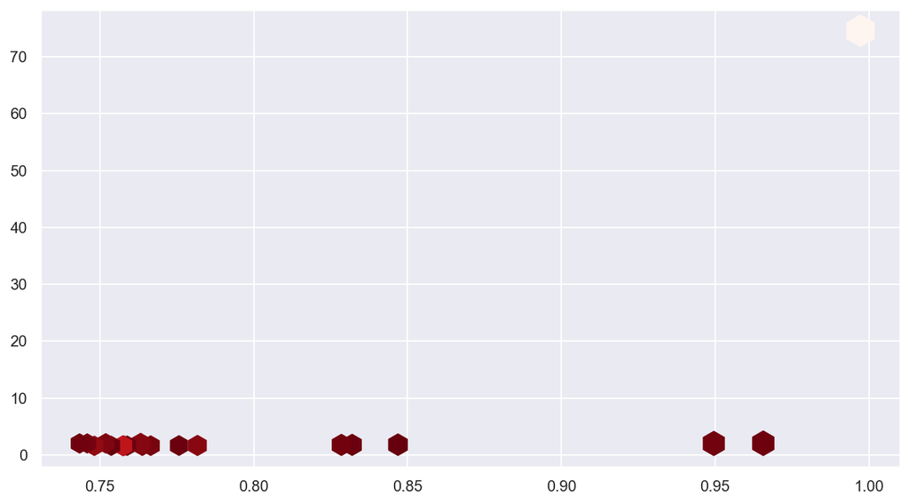

```python
tempDF = StateDF.sort_values(by='置信度' , ascending=False).head(20)
colors = tempDF['IR']
area = np.pi * (tempDF['Kulc']*20)**2
# 画散点图
plt.scatter(x=tempDF['置信度'], y=tempDF['Lift'], s=area, c=colors,cmap=plt.cm.Reds, alpha=1, marker='h')
```